# 2575647_Talluri janardhanakrishna

# 2

what are the ten most common movie names of all time?

which three years of the 1930s saw the most films released?

Plot the number of films that have been released each decade over the history of cinema.

Plot the number of "Hamlet" films made each decade.

Plot the number of "Rustler" characters in each decade of the history of film.

Plot the number of "Hamlet" characters each decade.

What are the 11 most common character names in movie history?

Who are the 10 people most often credited as "Herself" in film history?

Who are the 10 people most often credited as "Himself" in film history?

Which actors or actresses appeared in the most movies in the year 1945?

Which actors or actresses appeared in the most movies in the year 1985?

Plot how many roles Mammootty has played in each year of his career.

What are the 10 most frequent roles that start with the phrase "Patron in"?

What are the 10 most frequent roles that start with the word "Science"?

Plot the n-values of the roles that Judi Dench has played over her career.

Plot the n-values of Cary Grant's roles through his career.

How many leading (n=1) roles were available to actors, and how many to actresses, in the 1950s?

How many supporting (n=2) roles were available to actors, and how many to actresses, in the 1950s?

```python
%matplotlib inline
import pandas as pd
import seaborn as sbn
sbn.set()
```

```python
titles = pd.read_csv('titles.csv')
titles.head()
```

|  | title | year |
| --- | --- | --- |
| 0 | Tasveer Mere Sanam | 1996 |
| 1 | Only You | 1994 |
| 2 | El pueblo del terror | 1970 |
| 3 | Machine | 2007 |
| 4 | MARy | 2008 |

```python
titles = pd.read_csv('data/titles.csv', index_col=None)
titles.head()
```

|  | title | year |
| --- | --- | --- |
| 0 | Tasveer Mere Sanam | 1996 |
| 1 | Only You | 1994 |
| 2 | El pueblo del terror | 1970 |
| 3 | Machine | 2007 |
| 4 | MARy | 2008 |

```python
cast = pd.read_csv('data/cast.csv', index_col=None)
cast.head()
```

|  | title | year | name | type | character | n |
| --- | --- | --- | --- | --- | --- | --- |
| 0 | Closet Monster | 2015 | Buffy #1 | actor | Buffy 4 | 31.0 |
| 1 | Suuri illusioni | 1985 | Homo $ | actor | Guests | 22.0 |
| 2 | Battle of the Sexes | 2017 | $hutter | actor | Bobby Riggs Fan | 10.0 |
| 3 | Secret in Their Eyes | 2015 | $hutter | actor | 2002 Dodger Fan | NaN |
| 4 | Steve Jobs | 2015 | $hutter | actor | 1988 Opera House Patron | NaN |

```python
1.what are the Ten most common movie names of all time
```

```python
import pandas as pd
title_counts = titles['title'].value_counts()

top_10_common_titles = title_counts.head(10)

print(top_10_common_titles)
```

```
Hamlet                  20
Carmen                  17
Macbeth                 16
The Outsider            12
Maya                    12
Temptation              12
Freedom                 11
Honeymoon               11
Othello                 11
The Three Musketeers    11
Name: title, dtype: int64
```

```python
2.which three years of 1930s saw the most films released
```

```python
import pandas as pd
movies_1930s = titles[(titles['year'] >= 1930) & (titles['year'] <= 1939)]
top_3_years=movies_1930s.head(3)
print(top_3_years)
```

```
                title  year
13            Big Boy  1930
14    Come On, Tarzan  1932
19  One Night of Love  1934
```

3. Plot the number of films that have been released each decade over the history of cinema.

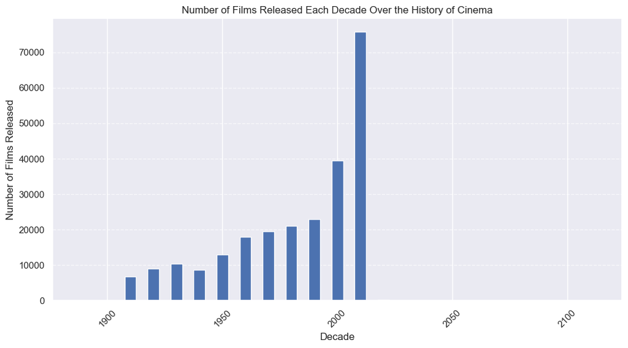

```python
import pandas as pd
import matplotlib.pyplot as plt

yearly_movie_counts = titles['year'].value_counts().reset_index()
yearly_movie_counts.columns = ['year', 'count']

# Define a function to round the year to the nearest decade
def round_to_decade(year):
    return int(year // 10 * 10)

# Apply the rounding function to create a 'decade' column
yearly_movie_counts['decade'] = yearly_movie_counts['year'].apply(round_to_decade)

# Group the data by decade and sum the counts
decade_movie_counts = yearly_movie_counts.groupby('decade')['count'].sum().reset_index()

plt.figure(figsize=(12, 6))
plt.bar(decade_movie_counts['decade'], decade_movie_counts['count'], width=5, align='center')
plt.xlabel('Decade')
plt.ylabel('Number of Films Released')
plt.title('Number of Films Released Each Decade Over the History of Cinema')
plt.xticks(rotation=45)
plt.grid(axis='y', linestyle='--', alpha=0.7)
plt.show()
```

4. Plot the number of "Hamlet" films made each decade.

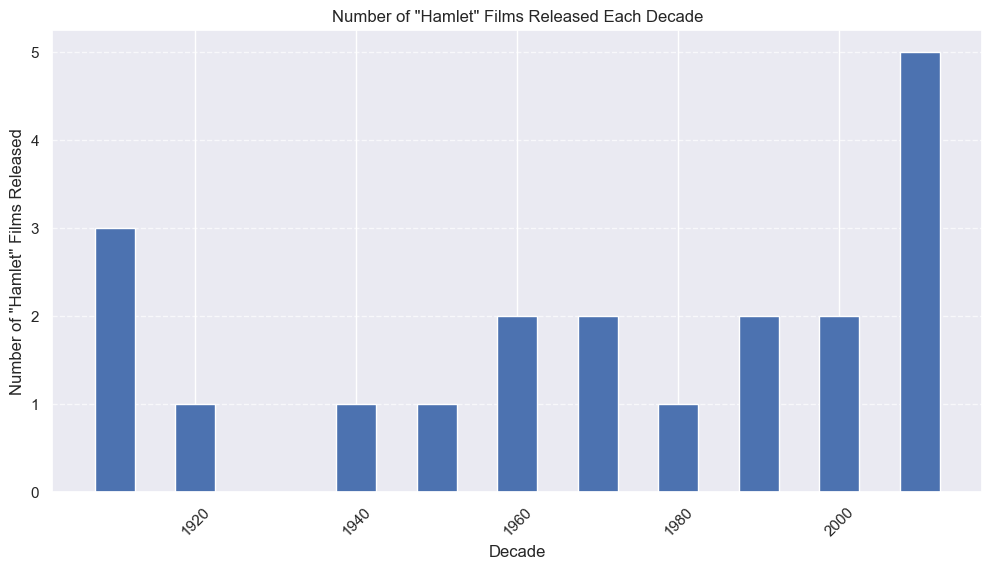

```python
import pandas as pd
import matplotlib.pyplot as plt

hamlet_movies = titles[titles['title'] == 'Hamlet']

# Create a DataFrame with the count of "Hamlet" films released each year
hamlet_yearly_counts = hamlet_movies['year'].value_counts().reset_index()
hamlet_yearly_counts.columns = ['year', 'count']

# Define a function to round the year to the nearest decade
def round_to_decade(year):
    return int(year // 10 * 10)

# Apply the rounding function to create a 'decade' column
hamlet_yearly_counts['decade'] = hamlet_yearly_counts['year'].apply(round_to_decade)

# Group the data by decade and sum the counts
hamlet_decade_counts = hamlet_yearly_counts.groupby('decade')['count'].sum().reset_index()

# Create a bar plot
plt.figure(figsize=(12, 6))
plt.bar(hamlet_decade_counts['decade'], hamlet_decade_counts['count'], width=5, align='center')
plt.xlabel('Decade')
plt.ylabel('Number of "Hamlet" Films Released')
plt.title('Number of "Hamlet" Films Released Each Decade')
plt.xticks(rotation=45)
plt.grid(axis='y', linestyle='--', alpha=0.7)
plt.show()
```

5. Plot the number of "Rustler" characters in each decade of the history of film.

[figure not shown]

```python
import pandas as pd
import matplotlib.pyplot as plt

# Assuming you have a DataFrame named 'titles' with a 'year' and 'title' column
# If not, load your data first using pd.read_csv() or another appropriate method

# Filter characters with the name "Rustler"
rustler_characters = titles[titles['title'] == 'Rustler']

# Create a DataFrame with the count of "Rustler" characters by year
rustler_yearly_counts = rustler_characters['year'].value_counts().reset_index()
rustler_yearly_counts.columns = ['year', 'count']

# Define a function to round the year to the nearest decade
def round_to_decade(year):
    return int(year // 10 * 10)

# Apply the rounding function to create a 'decade' column
rustler_yearly_counts['decade'] = rustler_yearly_counts['year'].apply(round_to_decade)

# Group the data by decade and sum the counts
rustler_decade_counts = rustler_yearly_counts.groupby('decade')['count'].sum().reset_index()

# Create a bar plot
plt.figure(figsize=(12, 6))
plt.bar(rustler_decade_counts['decade'], rustler_decade_counts['count'], width=5, align='center')
plt.xlabel('Decade')
plt.ylabel('Number of "Rustler" Characters')
plt.title('Number of "Rustler" Characters Each Decade in Film History')
plt.xticks(rotation=45)
plt.grid(axis='y', linestyle='--', alpha=0.7)
plt.show()
```

```python
6. Plot the number of "Hamlet" characters each decade.
```

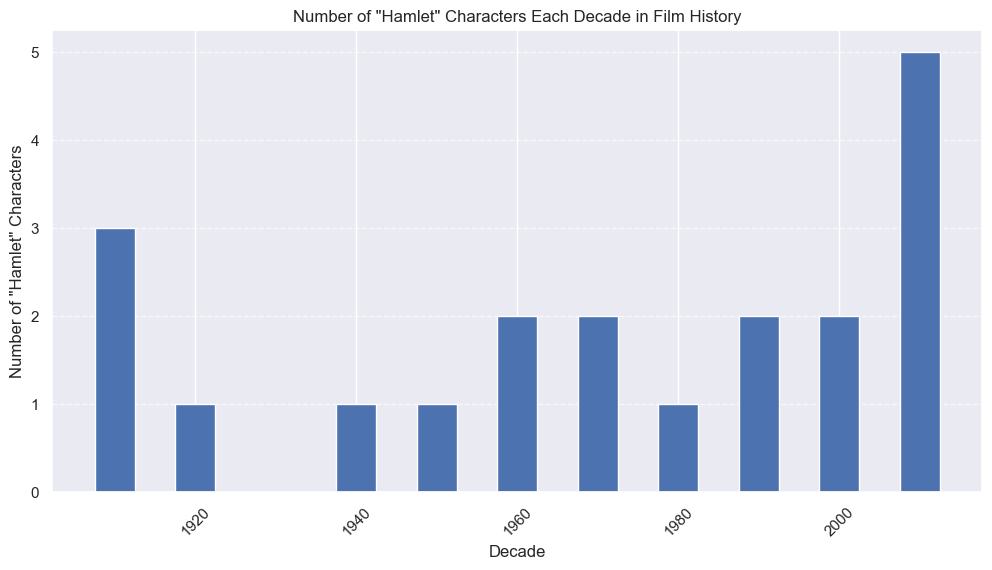

```python
import pandas as pd
import matplotlib.pyplot as plt

hamlet_characters = titles[titles['title'] == 'Hamlet']

# Create a DataFrame with the count of "Hamlet" characters by year
hamlet_yearly_counts = hamlet_characters['year'].value_counts().reset_index()
hamlet_yearly_counts.columns = ['year', 'count']

# Define a function to round the year to the nearest decade
def round_to_decade(year):
    return int(year // 10 * 10)

# Apply the rounding function to create a 'decade' column
hamlet_yearly_counts['decade'] = hamlet_yearly_counts['year'].apply(round_to_decade)

# Group the data by decade and sum the counts
hamlet_decade_counts = hamlet_yearly_counts.groupby('decade')['count'].sum().reset_index()

# Create a bar plot
plt.figure(figsize=(12, 6))
plt.bar(hamlet_decade_counts['decade'], hamlet_decade_counts['count'], width=5, align='center')
plt.xlabel('Decade')
plt.ylabel('Number of "Hamlet" Characters')
plt.title('Number of "Hamlet" Characters Each Decade in Film History')
plt.xticks(rotation=45)
plt.grid(axis='y', linestyle='--', alpha=0.7)
plt.show()
```

7. What are the 11 most common character names in movie history?

```python
import pandas as pd

character_name_counts = titles['name'].value_counts().reset_index()
character_name_counts.columns = ['Character Name', 'Count']

# Get the 11 most common character names
top_11_character_names = character_name_counts.head(11)

print(top_11_character_names)
```

[output not shown]

8. Who are the 10 people most often credited as "Herself" in film history?

```python
import pandas as pd
cast = pd.read_csv('data/cast.csv')
herself_credits = cast[cast['character'] == 'Herself']

# Count the occurrences of each person credited as "Herself"
herself_credit_counts = herself_credits['name'].value_counts().reset_index()
herself_credit_counts.columns = ['Person', 'Count']

# Get the top 10 people most often credited as "Herself"
top_10_herself_credits = herself_credit_counts.head(10)

print(top_10_herself_credits)
```

```
                      Person  Count
0         Queen Elizabeth II     12
1             Joyce Brothers      9
2                Luisa Horga      9
3     Mar?a Luisa (V) Mart?n      9
4          Margaret Thatcher      8
5            Hillary Clinton      8
6           In?s J. Southern      6
7  Mar?a Isabel (III) Mart?n      6
8             Marta Berrocal      6
9                Sumie Sakai      6
```

# 9. Who are the 10 people most often credited as "Himself" in film history?

```python
import pandas as pd

# Load the data from 'cast.csv' (assuming the CSV file has a 'name' and 'character' column)
cast = pd.read_csv('data/cast.csv')

# Filter for credits with the character name "Himself"
himself_credits = cast[cast['character'] == 'Himself']

# Count the occurrences of each person credited as "Himself"
himself_credit_counts = himself_credits['name'].value_counts().reset_index()
himself_credit_counts.columns = ['Person', 'Count']

# Get the top 10 people most often credited as "Himself"
top_10_himself_credits = himself_credit_counts.head(10)

print(top_10_himself_credits)
```

```
                  Person  Count
0           Adolf Hitler     99
1          Richard Nixon     44
2          Ronald Reagan     41
3        John F. Kennedy     37
4         George W. Bush     25
5      Winston Churchill     24
6     Martin Luther King     23
7             Ron Jeremy     22
8           Bill Clinton     22
9  Franklin D. Roosevelt     21
```

10. Which actors or actresses appeared in the most movies in the year 1945?

```python
import pandas as pd

cast = pd.read_csv('data/cast.csv')
movies_1945 = cast[cast['year'] == 1945]

# Count the appearances of each actor/actress
actor_appearances = movies_1945['name'].value_counts().reset_index()
actor_appearances.columns = ['Actor/Actress', 'Number of Appearances']

# Get the actor/actress with the most appearances
most_appearances = actor_appearances.head(3)

print(most_appearances)
```

```
     Actor/Actress  Number of Appearances
0     Emmett Vogan                     39
1  Sam (II) Harris                     33
2     Bess Flowers                     29
```

11. Which actors or actresses appeared in the most movies in the year 1985?

```python
import pandas as pd
cast = pd.read_csv('data/cast.csv')

# Filter for movies released in the year 1985
movies_1985 = cast[cast['year'] == 1985]

# Count the appearances of each actor/actress
actor_appearances = movies_1985['name'].value_counts().reset_index()
actor_appearances.columns = ['Actor/Actress', 'Number of Appearances']

top_n_appearances = actor_appearances.head(3)

print(top_n_appearances)
```

```
   Actor/Actress  Number of Appearances
0      Mammootty                     22
1  Shakti Kapoor                     21
2       Sukumari                     20
```

12. Plot how many roles Mammootty has played in each year of his career.

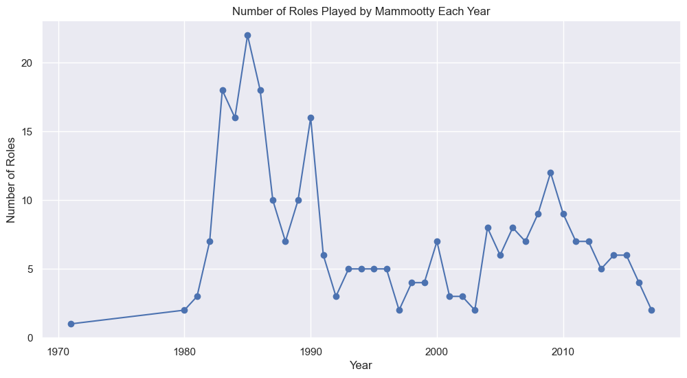

```python
import pandas as pd
import matplotlib.pyplot as plt

# Load the data from 'cast.csv' (assuming the CSV file has relevant columns)
cast = pd.read_csv('data/cast.csv')

# Filter for roles played by Mammootty
mammootty_roles = cast[cast['name'] == 'Mammootty']

# Group the roles by year and count the number of roles in each year
roles_by_year = mammootty_roles.groupby('year').size().reset_index(name='Number of Roles')

# Create a line plot
plt.figure(figsize=(12, 6))
plt.plot(roles_by_year['year'], roles_by_year['Number of Roles'], marker='o', linestyle='-', color='b')
plt.xlabel('Year')
plt.ylabel('Number of Roles')
plt.title('Number of Roles Played by Mammootty Each Year')
plt.grid(True)
plt.show()
```

13. What are the 10 most frequent roles that start with the phrase "Patron in"?

```python
import pandas as pd
cast = pd.read_csv('data/cast.csv')

# Filter for roles that start with the phrase "Patron in"
patron_roles = cast[cast['character'].str.startswith('Patron in')]

# Count the occurrences of each patron role
patron_role_counts = patron_roles['character'].value_counts().reset_index()
patron_role_counts.columns = ['Role', 'Count']

# Get the top 10 most frequent patron roles
top_10_patron_roles = patron_role_counts.head(10)

print(top_10_patron_roles)
```

```
                           Role  Count
0       Patron in Frisky Rabbit     16
1  Patron in Chinese Restaurant      9
2    Patron in the Coffee House      9
3     Patron in Billiard Parlor      5
4          Patron in restaurant      4
5                 Patron in Bar      4
6             Patron in cabaret      3
7          Patron in Restaurant      3
8                Patron in Club      3
9               Patron in booth      2
```

14. What are the 10 most frequent roles that start with the word "Science"?

```python
import pandas as pd

cast = pd.read_csv('data/cast.csv')

# Filter for roles that start with the word "Science"
science_roles = cast[cast['character'].str.startswith('Science')]

# Count the occurrences of each science role
science_role_counts = science_roles['character'].value_counts().reset_index()
science_role_counts.columns = ['Role', 'Count']

# Get the top 10 most frequent science roles
top_10_science_roles = science_role_counts.head(10)

print(top_10_science_roles)
```

```
                   Role  Count
0       Science Teacher     60
1       Science Student      9
2  Science Fair Student      9
3    Science Fair Judge      6
4      Science Fair Kid      5
5      Science Reporter      5
6           Science Kid      5
7   Science Club Member      5
8   Science Promo Cadet      5
9               Science      4
```

15. Plot the n-values of the roles that Judi Dench has played over her career.

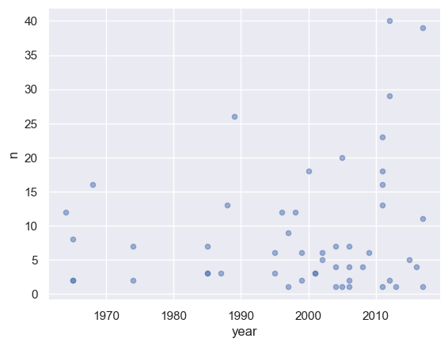

```python
c=cast[cast.name=="Judi Dench"]
#c.n.value_counts().sort_index().plot(kind="bar")
c.plot(kind="scatter",x='year',y='n',alpha=0.5)
```

16. Plot the n-values of Cary Grant's roles through his career.

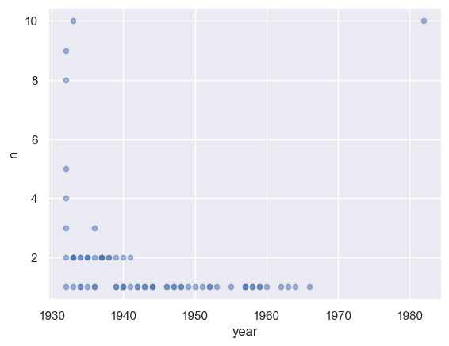

```python
d=cast[cast.name=="Cary Grant"]
#c.n.value_counts().sort_index().plot(kind="bar")
d.plot(kind="scatter",x='year',y='n',alpha=0.5)
```

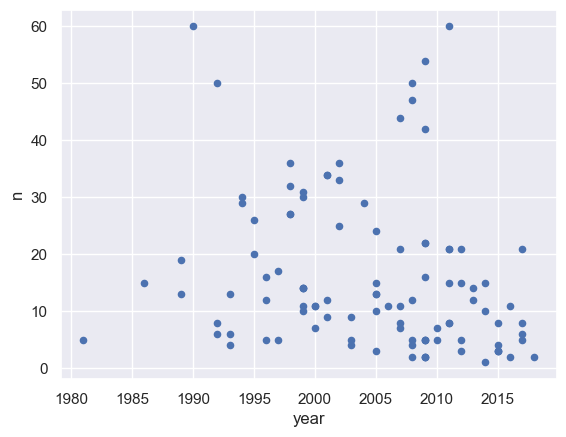

```python
cast[cast.name=='Ron Jeremy'].plot(kind='scatter',x='year',y='n')
```

18. How many leading (n=1) roles were available to actors, and how many to actresses, in the 1950s?

```python
cast[(cast.year//10==195)&(cast.n==1)].type.value_counts()
```

```
actor      6692
actress    3040
Name: type, dtype: int64
```

19. How many supporting (n=2) roles were available to actors, and how many to actresses, in the 1950s?

```python
cast[(cast.year//10==195)&(cast.n==2)].type.value_counts()
```

```
actor      4640
actress    4635
Name: type, dtype: int64
```

# 1

How many movies are listed in the titles dataframe?

What are the earliest two films listed in the titles dataframe?

How many movies have the title "Hamlet"?

How many movies are titled "North by Northwest"?

When was the first movie titled "Hamlet" made?

List all of the "Treasure Island" movies from earliest to most recent.

How many movies were made in the year 1950?

How many movies were made in the year 1960?

How many movies were made from 1950 through 1959?

In what years has a movie titled "Batman" been released?

How many roles were there in the movie "Inception"?

How many roles in the movie "Inception" are NOT ranked by an "n" value?

But how many roles in the movie "Inception" did receive an "n" value?

Display the cast of "North by Northwest" in their correct "n"-value order, ignoring roles that did not earn a numeric "n" value.

Display the entire cast, in "n"-order, of the 1972 film "Sleuth".

Now display the entire cast, in "n"-order, of the 2007 version of "Sleuth".

How many roles were credited in the silent 1921 version of Hamlet?

How many roles were credited in Branagh’s 1996 Hamlet?

How many "Hamlet" roles have been listed in all film credits through history?

How many people have played an "Ophelia"?

How many people have played a role called "The Dude"?

How many people have played a role called "The Stranger"?

How many roles has Sidney Poitier played throughout his career?

How many roles has Judi Dench played?

List the supporting roles (having n=2) played by Cary Grant in the 1940s, in order by year.

List the leading roles that Cary Grant played in the 1940s in order by year.

How many roles were available for actors in the 1950s?

How many roles were available for actresses in the 1950s?

How many leading roles (n=1) were available from the beginning of film history through 1980?

How many non-leading roles were available through from the beginning of film history through 1980?

How many roles through 1980 were minor enough that they did not warrant a numeric "n" rank?

1. How many movies are listed in the titles dataframe?

```python
import pandas as pd

df = pd.read_csv("data/titles.csv")

num_movies = len(df)

print(f'Total number of movies listed: {num_movies}')
```

```
Total number of movies listed: 244914
```

2. What are the earliest two films listed in the titles dataframe?

```python
import pandas as pd

df = pd.read_csv("data/titles.csv")

df_sorted = df.sort_values(by='year')

earliest_films = df_sorted.head(2)

print("The earliest two films listed:")
print(earliest_films[['title', 'year']])
```

```
The earliest two films listed:
                     title  year
193222          Miss Jerry  1894
51388   The Startled Lover  1898
```

3. How many movies have the title "Hamlet"?

```python
import pandas as pd

csv_file = "data/titles.csv"

df = pd.read_csv(csv_file)

hamlet_movies = df[df['title'] == 'Hamlet']

num_hamlet_movies = hamlet_movies.shape[0]

print(f'The number of movies with the title "Hamlet" is: {num_hamlet_movies}')
```

```
The number of movies with the title "Hamlet" is: 20
```

4. How many movies are titled "North by Northwest"?

```python
import pandas as pd

csv_file = "data/titles.csv"

df = pd.read_csv(csv_file)

north_by_northwest_movies = df[df['title'] == 'North by Northwest']

num_north_by_northwest_movies = north_by_northwest_movies.shape[0]

print(f'The number of movies titled "North by Northwest" is: {num_north_by_northwest_movies}')
```

```
The number of movies titled "North by Northwest" is: 1
```

5. When was the first movie titled "Hamlet" made?

```python
import pandas as pd

csv_file = "data/titles.csv"

df = pd.read_csv(csv_file)

hamlet_movies = df[df['title'] == 'Hamlet']

hamlet_movies = hamlet_movies.sort_values(by='year')

first_hamlet_movie_year = hamlet_movies.iloc[0]['year']

print(f'The first movie titled "Hamlet" was made in the year: {first_hamlet_movie_year}')
```

```
The first movie titled "Hamlet" was made in the year: 1910
```

6. How many movies were made in the year 1950?

```python
import pandas as pd

csv_file = "data/titles.csv"

df = pd.read_csv(csv_file)

movies_1950 = df[df['year'] == 1950]

num_movies_1950 = movies_1950.shape[0]

print(f'The number of movies made in the year 1950 is: {num_movies_1950}')
```

```
The number of movies made in the year 1950 is: 1113
```

7. How many movies were made in the year 1960?

```python
import pandas as pd

csv_file = "data/titles.csv"

df = pd.read_csv(csv_file)

movies_1960 = df[df['year'] == 1960]

num_movies_1960 = movies_1960.shape[0]

print(f'The number of movies made in the year 1960 is: {num_movies_1960}')
```

```
The number of movies made in the year 1960 is: 1549
```

8. How many movies were made from 1950 through 1959?

```python
import pandas as pd

csv_file = "data/titles.csv"

df = pd.read_csv(csv_file)

movies_1950s = df[(df['year'] >= 1950) & (df['year'] <= 1959)]

num_movies_1950s = movies_1950s.shape[0]

print(f'The number of movies made from 1950 through 1959 is: {num_movies_1950s}')
```

```
The number of movies made from 1950 through 1959 is: 12934
```

9. In what years has a movie titled "Batman" been released?

```python
import pandas as pd

csv_file = "data/titles.csv"

df = pd.read_csv(csv_file)

batman_movies = df[df['title'] == 'Batman']

unique_years = batman_movies['year'].unique()

print(f'Years in which a movie titled "Batman" has been released: {unique_years}')
```

```
Years in which a movie titled "Batman" has been released: [1943 1989]
```

10. How many roles were there in the movie "Inception"?

```python
import pandas as pd

csv_file = "data/cast.csv"

df = pd.read_csv(csv_file)

inception_roles = df[df['title'] == 'Inception']

num_roles_inception = inception_roles['character'].nunique()

print(f'The number of roles in the movie "Inception" is: {num_roles_inception}')
```

[output not shown]

11. How many roles in the movie "Inception" are NOT ranked by an "n" value?

```python
import pandas as pd

csv_file = "data/cast.csv"

df = pd.read_csv(csv_file)

inception_roles = df[df['title'] == 'Inception']

num_unranked_roles = inception_roles['n'].isna().sum()

print(f'The number of roles in the movie "Inception" that are not ranked by an "n" value is: {num_unranked_roles}')
```

```
The number of roles in the movie "Inception" that are not ranked by an "n" value is: 27
```

12. But how many roles in the movie "Inception" did receive an "n" value?¶

```python
import pandas as pd

csv_file = "data/cast.csv"

df = pd.read_csv(csv_file)

inception_roles = df[df['title'] == 'Inception']

num_ranked_roles = inception_roles['n'].notna().sum()

print(f'The number of roles in the movie "Inception" that received an "n" value is: {num_ranked_roles}')
```

```
The number of roles in the movie "Inception" that received an "n" value is: 51
```

13. Display the cast of "North by Northwest" in their correct "n"-value order, ignoring roles that did not earn a numeric "n" value.

```python
import pandas as pd

csv_file = "data/cast.csv"

df = pd.read_csv(csv_file)

north_by_northwest_cast = df[(df['title'] == 'North by Northwest') & df['n'].notna()]

north_by_northwest_cast['n'] = pd.to_numeric(north_by_northwest_cast['n'])

north_by_northwest_cast = north_by_northwest_cast.sort_values(by='n')

print(north_by_northwest_cast[['name', 'character', 'n']])
```

```
                         name                    character     n
871426             Cary Grant           Roger O. Thornhill   1.0
3518333       Eva Marie Saint                  Eve Kendall   2.0
1457165           James Mason              Phillip Vandamm   3.0
3157232   Jessie Royce Landis              Clara Thornhill   4.0
356707         Leo G. Carroll                The Professor   5.0
3048272  Josephine Hutchinson                Mrs. Townsend   6.0
1695173           Philip Ober              Lester Townsend   7.0
1275337         Martin Landau                      Leonard   8.0
2447081         Adam Williams                     Valerian   9.0
1811387          Edward Platt              Victor Larrabee  10.0
665768      Robert Ellenstein                        Licht  11.0
2295714          Les Tremayne                   Auctioneer  12.0
464736        Philip Coolidge                    Dr. Cross  13.0
1508344         Patrick McVey               Sergeant Flamm  14.0
206471           Edward Binns               Captain Junket  15.0
1384780             Ken Lynch  Charley - Chicago Policeman  16.0
```

[output not shown]

14 . Display the entire cast, in "n"-order, of the 1972 film "Sleuth"

```python
import pandas as pd

csv_file = "data/cast.csv"

df = pd.read_csv(csv_file)

sleuth_1972_cast = df[(df['title'] == 'Sleuth') & (df['year'] == 1972)]

sleuth_1972_cast = sleuth_1972_cast.sort_values(by='n')

print(sleuth_1972_cast[['name', 'character', 'n']])
```

```
                       name                   character    n
1705394    Laurence Olivier                 Andrew Wyke  1.0
326773        Michael Caine                 Milo Tindle  2.0
373876       Alec Cawthorne           Inspector Doppler  3.0
1465483  John (II) Matthews  Detective Sergeant Tarrant  4.0
2724553  Eve (III) Channing             Marguerite Wyke  5.0
1448690        Teddy Martin      Police Constable Higgs  6.0
```

15. Now display the entire cast, in "n"-order, of the 2007 version of "Sleuth"

```python
import pandas as pd

csv_file = "data/cast.csv"

df = pd.read_csv(csv_file)

sleuth_2007_cast = df[(df['title'] == 'Sleuth') & (df['year'] == 2007)]

sleuth_2007_cast = sleuth_2007_cast.sort_values(by='n')

print(sleuth_2007_cast[['name', 'character', 'n']])
```

```
                        name          character    n
326774         Michael Caine             Andrew  1.0
1293634             Jude Law               Milo  2.0
1805907        Harold Pinter        Man on T.V.  3.0
260242       Kenneth Branagh  Other Man on T.V.  NaN
373877   Alec (II) Cawthorne  Inspector Doppler  NaN
2724552    Eve (II) Channing    Marguerite Wyke  NaN
3370424    Carmel O'Sullivan             Maggie  NaN
```

16. How many roles were credited in the silent 1921 version of Hamlet?

```python
import pandas as pd

csv_file = "data/cast.csv"

df = pd.read_csv(csv_file)

hamlet_1921_cast = df[(df['title'] == 'Hamlet') & (df['year'] == 1921)]

num_credited_roles = hamlet_1921_cast.shape[0]

print(f'The number of roles credited in the silent 1921 version of "Hamlet" is: {num_credited_roles}')
```

```
The number of roles credited in the silent 1921 version of "Hamlet" is: 9
```

17. How many roles were credited in Branagh's 1996 Hamlet?

```python
import pandas as pd

csv_file = "data/cast.csv"

df = pd.read_csv(csv_file)

branagh_hamlet_1996_cast = df[(df['title'] == 'Hamlet') & (df['year'] == 1996)]

num_credited_roles = branagh_hamlet_1996_cast.shape[0]

print(f'The number of credited roles in Kenneth Branagh\'s 1996 version of "Hamlet" is: {num_credited_roles}')
```

```
The number of credited roles in Kenneth Branagh's 1996 version of "Hamlet" is: 54
```

18. How many "Hamlet" roles have been listed in all film credits through history?

```python
import pandas as pd

csv_file = "data/cast.csv"

df = pd.read_csv(csv_file)

hamlet_roles = df[df['title'] == 'Hamlet']

num_hamlet_roles = hamlet_roles['character'].nunique()

print(f'The number of "Hamlet" roles listed in all film credits through history is: {num_hamlet_roles}')
```

```
The number of "Hamlet" roles listed in all film credits through history is: 112
```

19. How many people have played an "Ophelia"?

```python
import pandas as pd

csv_file = "data/cast.csv"

df = pd.read_csv(csv_file)

ophelia_roles = df[df['character'] == 'Ophelia']

num_ophelia_actors = ophelia_roles['name'].nunique()

print(f'The number of people who have played the role of "Ophelia" is: {num_ophelia_actors}')
```

```
The number of people who have played the role of "Ophelia" is: 115
```

20. How many people have played a role called "The Dude"?

```python
import pandas as pd

csv_file = "data/cast.csv"

df = pd.read_csv(csv_file)

the_dude_roles = df[df['character'] == 'The Dude']

num_the_dude_actors = the_dude_roles['name'].nunique()

print(f'The number of people who have played a role called "The Dude" is: {num_the_dude_actors}')
```

```
The number of people who have played a role called "The Dude" is: 19
```

21. How many people have played a role called "The Stranger"?¶

```python
import pandas as pd

csv_file = "data/cast.csv"

df = pd.read_csv(csv_file)

the_stranger_roles = df[df['character'] == 'The Stranger']

num_the_stranger_actors = the_stranger_roles['name'].nunique()

print(f'The number of people who have played a role called "The Stranger" is: {num_the_stranger_actors}')
```

```
The number of people who have played a role called "The Stranger" is: 202
```

22. How many roles has Sidney Poitier played throughout his career?¶

```python
import pandas as pd

csv_file = "data/cast.csv"

df = pd.read_csv(csv_file)

sidney_poitier_roles = df[df['name'] == 'Sidney Poitier']

num_sidney_poitier_roles = sidney_poitier_roles['character'].nunique()

print(f'Sidney Poitier has played {num_sidney_poitier_roles} roles throughout his career.')
```

```
Sidney Poitier has played 41 roles throughout his career.
```

23. How many roles has Judi Dench played?¶

```python
import pandas as pd

csv_file = "data/cast.csv"

df = pd.read_csv(csv_file)

judi_dench_roles = df[df['name'] == 'Judi Dench']

num_judi_dench_roles = judi_dench_roles['character'].nunique()

print(f'Judi Dench has played {num_judi_dench_roles} roles throughout her career.')
```

```
Judi Dench has played 46 roles throughout her career.
```

24. List the supporting roles (having n=2) played by Cary Grant in the 1940s, in order by year.¶

```python
import pandas as pd

csv_file = "data/cast.csv"

df = pd.read_csv(csv_file)

cary_grant_supporting_roles_1940s = df[(df['name'] == 'Cary Grant') & (df['n'] == 2) & (df['year'] >= 1940) & (df['year'] <= 1949)]

cary_grant_supporting_roles_1940s = cary_grant_supporting_roles_1940s.sort_values(by='year')

print(cary_grant_supporting_roles_1940s[['year', 'character']])
```

```
        year    character
871423  1940   Nick Arden
871433  1941  Roger Adams
```

25. List the leading roles that Cary Grant played in the 1940s in order by year

```python
import pandas as pd

csv_file = "data/cast.csv"

df = pd.read_csv(csv_file)

cary_grant_leading_roles_1940s = df[(df['name'] == 'Cary Grant') & (df['n'] == 1) & (df['year'] >= 1940) & (df['year'] <= 1949)]

cary_grant_leading_roles_1940s = cary_grant_leading_roles_1940s.sort_values(by='year')

print(cary_grant_leading_roles_1940s[['year', 'character']])
```

```
        year                             character
871448  1940                           Matt Howard
871407  1940                          Walter Burns
871450  1940                    C. K. Dexter Haven
871438  1941                      Johnnie Aysgarth
871452  1942                          Leopold Dilg
871429  1942                 Patrick 'Pat' O'Toole
871398  1943                         Capt. Cassidy
871422  1943  Joe Adams -posing as Joe Bascopolous
871430  1944                           Jerry Flynn
871390  1944                     Mortimer Brewster
871425  1944                            Ernie Mott
871424  1946                           Cole Porter
871427  1946                                Devlin
871444  1947                           Dick Nugent
871445  1947                                Dudley
871421  1948                         Jim Blandings
871402  1948                     Dr. Madison Brown
871411  1949                 Captain Henri Rochard
```

26. How many roles were available for actors in the 1950s?

```python
import pandas as pd

csv_file = "data/cast.csv"

df = pd.read_csv(csv_file)

roles_1950s = df[(df['year'] >= 1950) & (df['year'] <= 1959)]

num_roles_1950s = roles_1950s.shape[0]

print(f'The number of roles available for actors in the 1950s is: {num_roles_1950s}')
```

[output not shown]

27. How many roles were available for actresses in the 1950s?¶

```python
import pandas as pd

csv_file = "data/cast.csv"

df = pd.read_csv(csv_file)

actress_roles_1950s = df[(df['year'] >= 1950) & (df['year'] <= 1959) & (df['type'] == 'actress')]

num_actress_roles_1950s = actress_roles_1950s.shape[0]

print(f'The number of roles available for actresses in the 1950s is: {num_actress_roles_1950s}')
```

```
The number of roles available for actresses in the 1950s is: 57733
```

28. How many leading roles (n=1) were available from the beginning of film history through 1980?

```python
import pandas as pd

csv_file = "data/cast.csv"

df = pd.read_csv(csv_file)

leading_roles_until_1980 = df[(df['year'] <= 1980) & (df['n'] == 1)]

num_leading_roles_until_1980 = leading_roles_until_1980.shape[0]

print(f'The number of leading roles (n=1) available from the beginning of film history through 1980 is: {num_leading_roles_until_1980}')
```

```
The number of leading roles (n=1) available from the beginning of film history through 1980 is: 65140
```

29. How many non-leading roles were available through from the beginning of film history through 1980?

```python
import pandas as pd

csv_file = "data/cast.csv"

df = pd.read_csv(csv_file)

non_leading_roles_until_1980 = df[(df['year'] <= 1980) & (df['n'] != 1)]

num_non_leading_roles_until_1980 = non_leading_roles_until_1980.shape[0]

print(f'The number of non-leading roles (n values other than 1) available from the beginning of film history through 1980 is: {num_non_leading_roles_until_1980}')
```

```
The number of non-leading roles (n values other than 1) available from the beginning of film history through 1980 is: 1117667
```

30. How many roles through 1980 were minor enough that they did not warrant a numeric "n" rank?

```python
import pandas as pd

csv_file = "data/cast.csv"

df = pd.read_csv(csv_file)

roles_without_n_rank_until_1980 = df[(df['year'] <= 1980) & df['n'].isna()]

num_roles_without_n_rank_until_1980 = roles_without_n_rank_until_1980.shape[0]

print(f'The number of roles through 1980 that did not warrant a numeric "n" rank is: {num_roles_without_n_rank_until_1980}')
```

```
The number of roles through 1980 that did not warrant a numeric "n" rank is: 448347
```

# 3

Using groupby(), plot the number of films that have been released each decade in the history of cinema.

Using groupby() to plot the number of "Hamlet"films made each decade?

How many leading (n=1) roles were available to actors, and how many to actresses, in each year of the 1950s?

In the 1950s decade taken as a whole, how many total roles were available to actors, and how many to actresses, for each "n" number 1 through 5?

Use groupby() to determine how many roles are listed for each of the Pink Panther movies.

List, in order by year, each of the films in which Frank Oz has played more than 1 role.

List each of the characters that Frank Oz has portrayed at least twice.

```python
titles = pd.read_csv('data/titles.csv', index_col=None)

titles.head()
```

|  | title | year |
| --- | --- | --- |
| 0 | Tasveer Mere Sanam | 1996 |
| 1 | Only You | 1994 |
| 2 | El pueblo del terror | 1970 |
| 3 | Machine | 2007 |
| 4 | MARy | 2008 |

1. Using groupby(), plot the number of films that have been released each decade in the history of cinema.

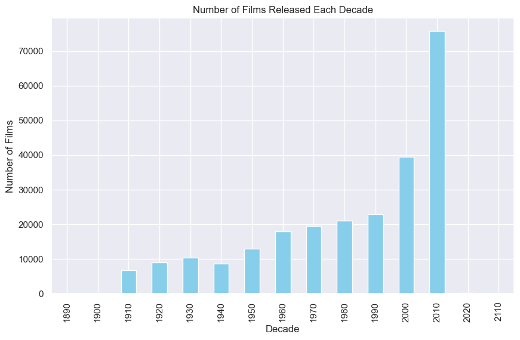

```python
# Assuming 'release_year' is the column name containing release years in the 'titles' DataFrame
# If it's named differently, please replace it with the correct column name
titles['decade'] = (titles['year'] // 10) * 10

# Group by decade and count the number of films
films_per_decade = titles.groupby('decade').size()

# Plotting
import matplotlib.pyplot as plt

plt.figure(figsize=(10, 6))
films_per_decade.plot(kind='bar', color='skyblue')
plt.title('Number of Films Released Each Decade')
plt.xlabel('Decade')
plt.ylabel('Number of Films')
plt.show()
```

2 Use groupby() to plot the number of "Hamlet" films made each decade.

[output not shown]

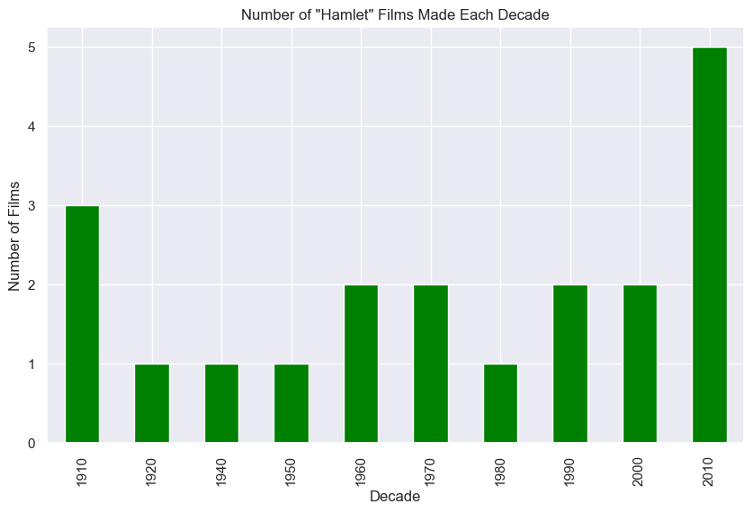

```python
# Filter the DataFrame for films with the title "Hamlet"
hamlet_films = titles[titles['title'] == 'Hamlet']

# Assuming 'release_year' is the column name containing release years
# If it's named differently, please replace it with the correct column name
hamlet_films['decade'] = (hamlet_films['year'] // 10) * 10

# Group by decade and count the number of "Hamlet" films
hamlet_films_per_decade = hamlet_films.groupby('decade').size()

# Plotting
import matplotlib.pyplot as plt

plt.figure(figsize=(10, 6))
hamlet_films_per_decade.plot(kind='bar', color='green')
plt.title('Number of "Hamlet" Films Made Each Decade')
plt.xlabel('Decade')
plt.ylabel('Number of Films')
plt.show()
```

3. How many leading (n=1) roles were available to actors, and how many to actresses, in each year of the 1950s?

```python
# Step 1: Filter roles from the 1950s
roles_1950s = cast[(cast['year'] >= 1950) & (cast['year'] <= 1959)]

# Step 2: Filter for leading roles
leading_roles = roles_1950s[roles_1950s['n'] == 1]

# Step 3: Group by year and gender
roles_by_year_gender = leading_roles.groupby(['year', 'type'])

# Step 4: Count the number of roles for each combination of year and gender
roles_count = roles_by_year_gender.size()

# Display the result
print(roles_count)
```

```
year  type
1950  actor      625
      actress    288
1951  actor      651
      actress    285
1952  actor      613
      actress    304
1953  actor      664
      actress    312
1954  actor      636
      actress    316
1955  actor      648
      actress    285
1956  actor      668
      actress    307
1957  actor      739
      actress    315
1958  actor      715
      actress    301
1959  actor      733
      actress    327
dtype: int64
```

4. In the 1950s decade taken as a whole, how many total roles were available to actors, and how many to actresses, for each "n" number 1 through 5?

```python
 Step 1: Filter roles from the 1950s
roles_1950s = cast[(cast['year'] >= 1950) & (cast['year'] <= 1959)]

# Step 2: Filter for roles with n values between 1 and 5
filtered_roles = roles_1950s[(roles_1950s['n'] >= 1) & (roles_1950s['n'] <= 5)]

# Step 3: Group by gender and n value
roles_by_gender_n = filtered_roles.groupby(['type', 'n'])

# Step 4: Count the number of roles for each combination of gender and n value
roles_count = roles_by_gender_n.size()

# Display the result
print(roles_count)
```

```
type     n
actor    1.0    6692
         2.0    4640
         3.0    5654
         4.0    5663
         5.0    5674
actress  1.0    3040
         2.0    4635
         3.0    3201
         4.0    2881
         5.0    2592
dtype: int64
```

5. Use groupby() to determine how many roles are listed for each of the Pink Panther movies.

```python
# Step 1: Filter roles from Pink Panther movies
pink_panther_roles = cast[cast['title'].str.contains('Pink Panther', case=False)]

# Step 2: Group by movie title
roles_by_movie = pink_panther_roles.groupby('title')

# Step 3: Count the number of roles for each movie
roles_count = roles_by_movie.size()

# Display the result
print(roles_count)
```

```
title
Curse of the Pink Panther          67
Revenge of the Pink Panther        68
Son of the Pink Panther            46
The Pink Panther                  111
The Pink Panther 2                 84
The Pink Panther Strikes Again     70
The Return of the Pink Panther     30
Trail of the Pink Panther          41
dtype: int64
```

6. List, in order by year, each of the films in which Frank Oz has played more than 1 role.

```python
# Step 1: Filter roles for Frank Oz
frank_oz_roles = cast[cast['name'] == 'Frank Oz']

# Step 2: Group by title and year, and count the number of roles
roles_per_film = frank_oz_roles.groupby(['title', 'year']).size()

# Step 3: Filter films where Frank Oz played more than one role
multiple_roles_films = roles_per_film[roles_per_film > 1]

# Display the result
print(multiple_roles_films)
```

```
title                                 year
An American Werewolf in London        1981    2
Follow That Bird                      1985    3
Muppet Treasure Island                1996    4
Muppets from Space                    1999    4
The Adventures of Elmo in Grouchland  1999    3
The Dark Crystal                      1982    2
The Great Muppet Caper                1981    6
The Muppet Christmas Carol            1992    7
The Muppet Movie                      1979    8
The Muppets Take Manhattan            1984    7
dtype: int64
```

7. List each of the characters that Frank Oz has portrayed at least twice

```python
# Step 1: Filter roles for Frank Oz
frank_oz_roles = cast[cast['name'] == 'Frank Oz']

# Step 2: Group by character name and count the number of times each character appears
character_appearances = frank_oz_roles.groupby('character').size()

# Step 3: Filter characters that Frank Oz has portrayed at least twice
characters_at_least_twice = character_appearances[character_appearances >= 2]

# Display the result
print(characters_at_least_twice)
```

```
character
Animal            6
Bert              3
Cookie Monster    5
Fozzie Bear       4
Grover            2
Miss Piggy        6
Sam the Eagle     5
Yoda              6
dtype: int64
```

# 4

Define a year as a "Superman year" whose films feature more Superman characters than Batman. How many years in film history have been Superman years?

How many years have been "Batman years", with more Batman characters than Superman characters?

Plot the number of actor roles each year and the number of actress roles each year over the history of film.

Plot the number of actor roles each year and the number of actress roles each year, but this time as a kind='area' plot.

Plot the difference between the number of actor roles each year and the number of actress roles each year over the history of film.

Plot the fraction of roles that have been 'actor' roles each year in the history of film.

Plot the fraction of supporting (n=2) roles that have been 'actor' roles each year in the history of film.

Build a plot with a line for each rank n=1 through n=3, where the line shows what fraction of that rank's roles were 'actor' roles for each year in the history of film.

```python
titles = pd.read_csv("data/titles.csv")
titles.head()
```

|  | title | year |
| --- | --- | --- |
| 0 | Tasveer Mere Sanam | 1996 |
| 1 | Only You | 1994 |
| 2 | El pueblo del terror | 1970 |
| 3 | Machine | 2007 |
| 4 | MARy | 2008 |

```python
import matplotlib.pyplot as plt
cast = pd.read_csv("data/cast.csv")
cast.head()
```

|  | title | year | name | type | character | n |
| --- | --- | --- | --- | --- | --- | --- |
| 0 | Closet Monster | 2015 | Buffy #1 | actor | Buffy 4 | 31.0 |
| 1 | Suuri illusioni | 1985 | Homo $ | actor | Guests | 22.0 |
| 2 | Battle of the Sexes | 2017 | $hutter | actor | Bobby Riggs Fan | 10.0 |
| 3 | Secret in Their Eyes | 2015 | $hutter | actor | 2002 Dodger Fan | NaN |
| 4 | Steve Jobs | 2015 | $hutter | actor | 1988 Opera House Patron | NaN |

1 Define a year as a "Superman year" whose films feature more Superman characters than Batman. How many years in film history have been Superman years?

```python
both = cast[(cast.character=='Superman') | (cast.character == 'Batman')].groupby(['year','character']).size().unstack().fillna(0)
diff = both.Superman - both.Batman
print("Superman: " + str(len(diff[diff>0])))
```

[output not shown]

2 How many years have been "Batman years", with more Batman characters than Superman characters?

```python
both = cast[(cast.character=='Superman') | (cast.character == 'Batman')].groupby(['year','character']).size().unstack().fillna(0)
diff = both.Batman - both.Superman
print("Batman: " + str(len(diff[diff>0])))
```

```
Batman: 27
```

3 Plot the number of actor roles each year and the number of actress roles each year over the history of film.

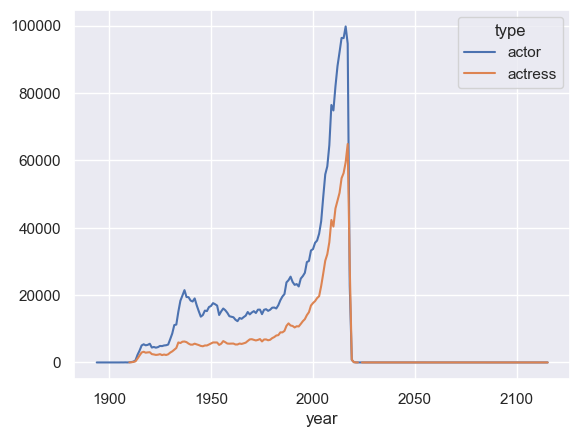

```python
cast.groupby(['year','type']).size().unstack().plot()
```

4 Plot the number of actor roles each year and the number of actress roles each year, but this time as a kind='area' plot.

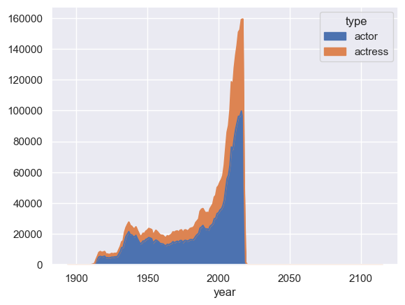

```python
cast.groupby(['year','type']).size().unstack().plot(kind='area')
```

5 Plot the difference between the number of actor roles each year and the number of actress roles each year over the history of film.

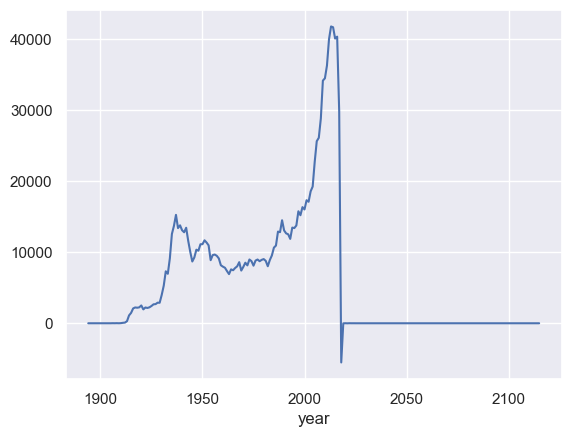

```python
foo = cast.groupby(['year','type']).size().unstack().fillna(0)
foo['diff'] = foo['actor']-foo['actress']
foo['diff'].plot()
```

# 6 Plot the fraction of roles that have been 'actor' roles each year in the hitsory of film.

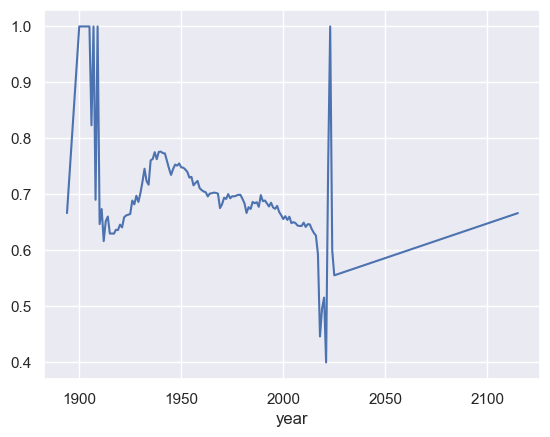

```python
foo['totalRoles'] = foo['actor']+foo['actress']
foo['manFrac'] = foo['actor']/foo['totalRoles']
foo['manFrac'].plot()
```

7 Plot the fraction of supporting (n=2) roles that have been 'actor' roles each year in the history of film.

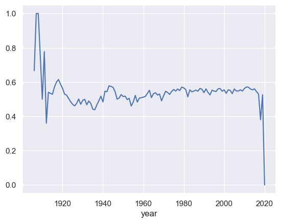

```python
support = cast[cast.n==2]
bar = support.groupby(['year','type']).size().unstack().fillna(0)
bar['totalRoles'] = bar['actor']+bar['actress']
bar['manFrac'] = bar['actor']/bar['totalRoles']
bar['manFrac'].plot()
```

8 Build a plot with a line for each rank n=1 through n=3, where the line shows what fraction of that rank's roles were 'actor' roles for each year in the history of film.

[figure not shown]

```python
def plot_actor_fraction_by_rank(cast, n):
    top_n_cast = cast[cast['n'] <= n]

    role_counts = top_n_cast.groupby(['year', 'type']).size().unstack(fill_value=0)

    role_counts['actor_fraction'] = role_counts['actor'] / (role_counts['actor'] + role_counts['actress'])

    plt.plot(role_counts.index, role_counts['actor_fraction'], label=f"Rank {n}")

plt.figure(figsize=(12, 6))
plt.xlabel('Year')
plt.ylabel('Fraction of Actor Roles')
plt.title('Fraction of Actor Roles by Rank')

for n in range(1, 4):
    plot_actor_fraction_by_rank(cast, n)

plt.legend()

plt.grid(True)
plt.show()
```

# 5

.Make a bar plot of the months in which movies with "Christmas" in their title tend to be released in the USA.

Make a bar plot of the months in which movies whose titles start with "The Hobbit" are released in the USA.

Make a bar plot of the day of the week on which movies with "Romance" in their title tend to be released in the USA.

Make a bar plot of the day of the week on which movies with "Action" in their title tend to be released in the USA.

On which date was each Judi Dench movie from the 1990s released in the USA?

In which months do films with Judi Dench tend to be released in the USA?

In which months do films with Tom Cruise tend to be released in the USA?

```python
import pandas as pd
import matplotlib.pyplot as plt
cast = pd.read_csv("data/cast.csv")
cast.head()
```

|  | title | year | name | type | character | n |
| --- | --- | --- | --- | --- | --- | --- |
| 0 | Closet Monster | 2015 | Buffy #1 | actor | Buffy 4 | 31.0 |
| 1 | Suuri illusioni | 1985 | Homo $ | actor | Guests | 22.0 |
| 2 | Battle of the Sexes | 2017 | $hutter | actor | Bobby Riggs Fan | 10.0 |
| 3 | Secret in Their Eyes | 2015 | $hutter | actor | 2002 Dodger Fan | NaN |
| 4 | Steve Jobs | 2015 | $hutter | actor | 1988 Opera House Patron | NaN |

```python
release_dates = pd.read_csv('data/release_dates.csv')
release_dates.head()
```

|  | title | year | country | date |
| --- | --- | --- | --- | --- |
| 0 | #73, Shaanthi Nivaasa | 2007 | India | 2007-06-15 |
| 1 | #BKKY | 2016 | Cambodia | 2017-10-12 |
| 2 | #Beings | 2015 | Romania | 2015-01-29 |
| 3 | #Captured | 2017 | USA | 2017-09-05 |
| 4 | #Ewankosau saranghaeyo | 2015 | Philippines | 2015-01-21 |

[output not shown]

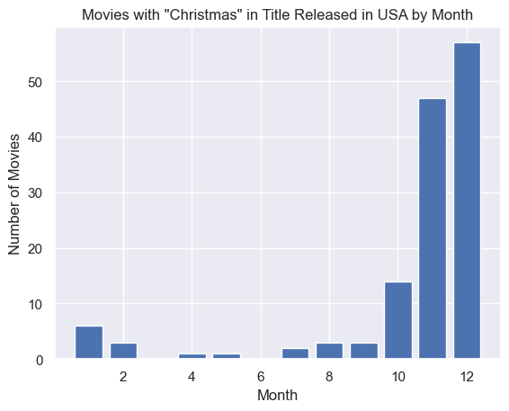

```python
import matplotlib.pyplot as plt

# Filter movies with "Christmas" in their title released in the USA
christmas_movies = release_dates_df[release_dates_df['title'].str.contains('Christmas', case=False) & (release_dates_df['country'] == 'USA')]

# Extract the month from the date column
christmas_movies.loc[:, 'month'] = pd.to_datetime(christmas_movies['date']).dt.month

# Count the occurrences of each month
christmas_month_counts = christmas_movies['month'].value_counts().sort_index()

# Plot the bar plot
plt.bar(christmas_month_counts.index, christmas_month_counts.values)
plt.xlabel('Month')
plt.ylabel('Number of Movies')
plt.title('Movies with "Christmas" in Title Released in USA by Month')
plt.show()
```

# Make a bar plot of the months in which movies whose titles start with"The Hobbit" are released in the USA

[output not shown]

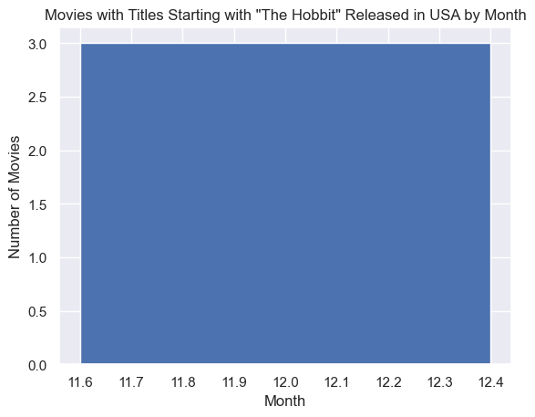

```python
# Filter movies with titles starting with "The Hobbit" released in the USA
hobbit_movies = release_dates_df[release_dates_df['title'].str.startswith('The Hobbit') & (release_dates_df['country'] == 'USA')]

# Extract the month from the date column
hobbit_movies['month'] = pd.to_datetime(hobbit_movies['date']).dt.month

# Count the occurrences of each month
hobbit_month_counts = hobbit_movies['month'].value_counts().sort_index()

# Plot the bar plot
plt.bar(hobbit_month_counts.index, hobbit_month_counts.values)
plt.xlabel('Month')
plt.ylabel('Number of Movies')
plt.title('Movies with Titles Starting with "The Hobbit" Released in USA by Month')
plt.show()
```

# Make a bar plot of the day of the week on which movies with"Romance" in their title tend to be released in the USA.

[output not shown]

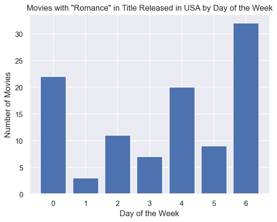

```python
# Filter movies with "Romance" in their title released in the USA
romance_movies = release_dates_df[release_dates_df['title'].str.contains('Romance', case=False) & (release_dates_df['country'] == 'USA')]

# Extract the day of the week from the date column
romance_movies['day_of_week'] = pd.to_datetime(romance_movies['date']).dt.dayofweek

# Count the occurrences of each day of the week
romance_day_counts = romance_movies['day_of_week'].value_counts().sort_index()

# Plot the bar plot
plt.bar(romance_day_counts.index, romance_day_counts.values)
plt.xlabel('Day of the Week')
plt.ylabel('Number of Movies')
plt.title('Movies with "Romance" in Title Released in USA by Day of the Week')
plt.show()
```

# Make a bar plot of the day of the week on which movies with "Action"in their title tend to be released in the USA.

[output not shown]

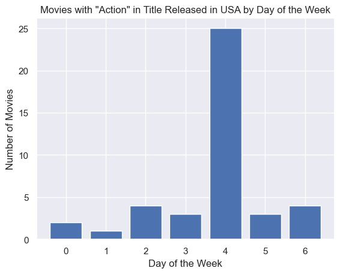

```python
# Filter movies with "Action" in their title released in the USA
action_movies = release_dates_df[release_dates_df['title'].str.contains('Action', case=False) & (release_dates_df['country'] == 'USA')]

# Extract the day of the week from the date column
action_movies['day_of_week'] = pd.to_datetime(action_movies['date']).dt.dayofweek

# Count the occurrences of each day of the week
action_day_counts = action_movies['day_of_week'].value_counts().sort_index()

# Plot the bar plot
plt.bar(action_day_counts.index, action_day_counts.values)
plt.xlabel('Day of the Week')
plt.ylabel('Number of Movies')
plt.title('Movies with "Action" in Title Released in USA by Day of the Week')
plt.show()
```

# On which date was each Judi Dench movie from the 1990s releasedin the USA?

```python
# Filter Judi Dench movies from the 1990s released in the USA
judi_dench_movies = cast_df[(cast_df['name'] == 'Judi Dench') & (cast_df['year'] >= 1990) & (cast_df['year'] < 2000)]

# Merge with release_dates_df to get the release dates
judi_dench_movies = judi_dench_movies.merge(release_dates_df, on=['title', 'year'])

# Filter movies released in the USA
judi_dench_movies_usa = judi_dench_movies[judi_dench_movies['country'] == 'USA']

# Display the release dates
print(judi_dench_movies_usa[['title', 'date']])
```

```
                       title        date
1                  GoldenEye  1995-11-17
40                    Hamlet  1996-12-25
71              Jack & Sarah  1996-03-22
78                 Mrs Brown  1997-10-03
101      Shakespeare in Love  1999-01-08
147       Tea with Mussolini  1999-05-14
173  The World Is Not Enough  1999-11-19
246      Tomorrow Never Dies  1997-12-19
```

# In which months do films with Judi Dench tend to be released in the USA?

[figure not shown]

```python
import matplotlib.pyplot as plt

# Filter movies with Judi Dench released in the USA
judi_dench_movies_usa = cast_df[(cast_df['name'] == 'Judi Dench') & (cast_df['type'] == 'actor')].merge(release_dates_df, on=['title', 'year'])

# Extract the month from the date column
judi_dench_movies_usa['month'] = pd.to_datetime(judi_dench_movies_usa['date']).dt.month

# Count the occurrences of each month
judi_dench_month_counts = judi_dench_movies_usa['month'].value_counts().sort_index()

# Plot the bar plot
plt.bar(judi_dench_month_counts.index, judi_dench_month_counts.values)
plt.xlabel('Month')
plt.ylabel('Number of Movies')
plt.title('Movies with Judi Dench Released in USA by Month')
plt.show()
```

# In which months do films with Tom Cruise tend to be released in the USA?

[figure not shown]

```python
# Filter movies with Tom Cruise released in the USA
tom_cruise_movies_usa = cast_df[(cast_df['name'] == 'Tom Cruise') & (cast_df['type'] == 'actor')].merge(release_dates_df, on=['title', 'year'])

# Extract the month from the date column
tom_cruise_movies_usa['month'] = pd.to_datetime(tom_cruise_movies_usa['date']).dt.month

# Count the occurrences of each month
tom_cruise_month_counts = tom_cruise_movies_usa['month'].value_counts().sort_index()

# Plot the bar plot
plt.bar(tom_cruise_month_counts.index, tom_cruise_month_counts.values)
plt.xlabel('Month')
plt.ylabel('Number of Movies')
plt.title('Movies with Tom Cruise Released in USA by Month')
plt.show()
```